# Heirarchial Clustering

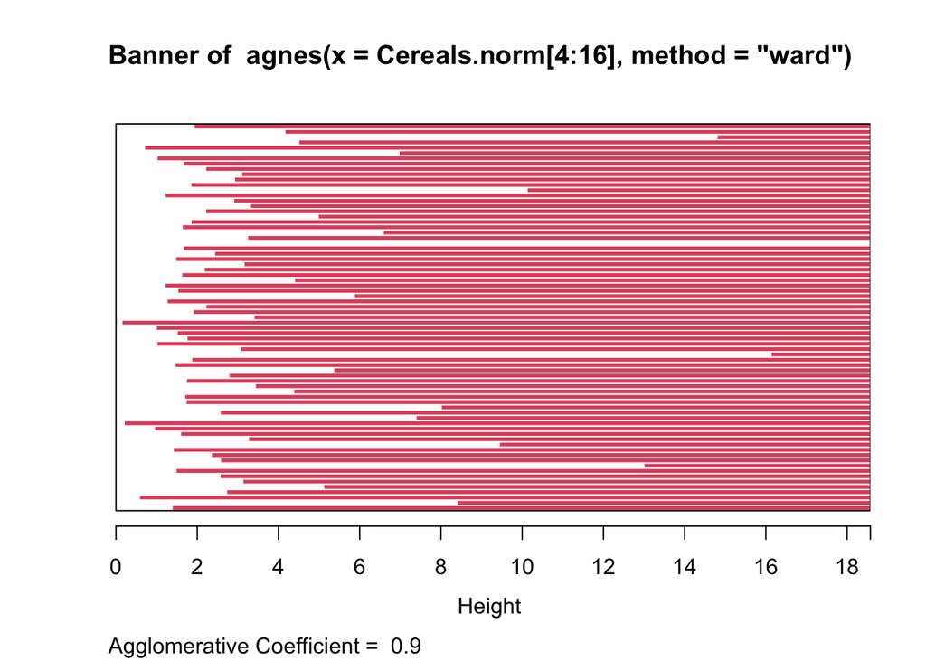

```r
# We find that there would be 6-clusters

# Visualize the 6 clusters
plot(hc_ward)
```

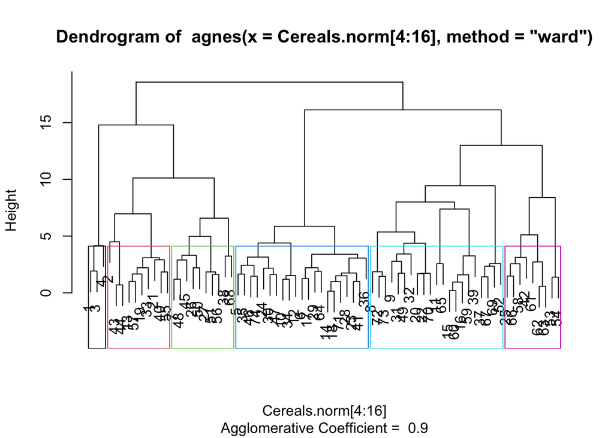

```r
rect.hclust(hc_ward, k = 6, border = 1:6)
```

Single linkage agglomerative coefficient: 0.607 Complete linkage agglomerative coefficient: 0.835 Average linkage agglomerative coefficient: 0.777 Ward agglomerative coefficient: 0.904

Since the ward agglomerative coefficient is the highest, this is the best linkage method

Hierarchical clustering produces consistent results, number of clusters picked from the dendrogram, and it takes hierarchical clustering longer to run

K-means is faster to run since computation time is linear, k-means starts with random number of clusters, and what number of clusters you want the data to be divided into (i.e. you set K)

Based on the dendrogram, there would be 6 clusters

```r
# Look at stability of the clusters
# 6 centers from what we found in the dendrogram
# Use nstart = 25 for 25 initial centroids
model <- kmeans(Cereals.norm[4:16], centers = 6, nstart = 25)
100 * model$betweenss / model$totss # Calculate percentage of those that stay in their cluster
```

```
## [1] 58.62927
```

```r
# We get 0.5863, or 58.63%

# We now want to look at healthy cereal groups
# We don't want to standardize because of the importance of the measurements for health priorities
# For instance, average (i.e. z = 0) sugar might be unhealthy because it is in reference to other sugars
# Use the unstandardized dataset
# Use k-means

# We want relevant health variables so only columns 4:12
cl <- kmeans(Cereals[4:12], centers = 6, nstart = 25)
Cereals <- data.frame(Cereals, cl$cluster)

# View the clusters
cl$centers
```

```
##   calories  protein       fat   sodium     fiber    carbo    sugars    potass
## 1 100.0000 3.333333 0.7777778 193.3333 7.0000000 11.00000  8.666667 248.88889
## 2 111.1538 2.192308 1.0000000 197.6923 1.4038462 15.75000  7.269231  70.96154
## 3 108.5714 1.571429 0.5714286 104.2857 0.5714286 11.57143 13.285714  30.00000
## 4  86.0000 2.500000 0.6000000   3.0000 2.1000000 14.60000  2.900000  95.00000
## 5 108.0000 2.400000 0.6000000 275.0000 0.5500000 19.35000  3.900000  51.00000
## 6 119.1667 3.250000 2.0833333 135.4167 2.5833333 13.41667  8.166667 127.91667
##   vitamins
## 1 33.33333
## 2 36.53846
## 3 25.00000
## 4 10.00000
## 5 32.50000
## 6 25.00000
```

The data shouldn’t be standardized because units matter here. When it comes to health, it is important to know the intake of certain food choices - such as fiber and potassium - more than just the z-score. An average amount of sugar, for instance, can still be unhealthy given the comparison of other cereals. As such, knowing what the unit is matters from a health perspective. We find that cluster 1 is likely the most healthy, since it is low calorie, high in protien, high in fiver, less carboydrates, and high in potassium and higher in vitamins

The advantages of hierarchical clustering is the fact that there is no domain knowledge needed to set the clusters, you can just use the dendrogram to deduce the number. Hierarchical clustering also is easy to implement and has consistent results. This allows replication to be done, an important step for confirming research. The dendrogram is easy to understand the breakdown of the different subgroups within the main category (for example healhy cereal for the cereal category)